# Title Practical Machine Learning Course Project

#Loading and PreProcessing the Data Data were obtained under the auspices of a Creative Common License from the GroupWare@LES Human Activity Recognition Lab. The purpose of the study was to use an on-body sensing apparatus to create a method that would allow the user to receive accurate and appropriate feedback not just on the quantitative aspects of their exerice performance, but also specifically tailored feed back on their qualitative execution. The experiment included six healthy individuals who were asked to perform one set of 10 repetitions of unilateral dumbbell bicep curls in five conditions: one with the correct techinque and 4 others with various forms of improper techinque. Data was collected from the onbody sensor in order to attempt to create a predictive algorithm via the aforementioned device containing an accelerometer which would allow the model to correctly interpret when the wearer is using proper vs. improper technique.

First we load the appropriate data packages and create a working directory, then read in the unzipped data obtained from the HAR Lab, in .csv format.

```r
temp <- tempfile()
download.file("https://d396qusza40orc.cloudfront.net/predmachlearn/pml-training.csv", temp,method="curl")
data <- read.csv(temp)
library(caret)
```

We then do a cursory series of data inspection to determine the integrity of the database.

```r
dim(data)
```

```
## [1] 19622   160
```

```r
str(data)
```

```
## 'data.frame':    19622 obs. of  160 variables:
##  $ X                       : int  1 2 3 4 5 6 7 8 9 10 ...
##  $ user_name               : Factor w/ 6 levels "adelmo","carlitos",..: 2 2 2 2 2 2 2 2 2 2 ...
##  $ raw_timestamp_part_1    : int  1323084231 1323084231 1323084231 1323084232 1323084232 1323084232 1323084232 1323084232 1323084232 1323084232 ...
##  $ raw_timestamp_part_2    : int  788290 808298 820366 120339 196328 304277 368296 440390 484323 484434 ...
##  $ cvtd_timestamp          : Factor w/ 20 levels "02/12/2011 13:32",..: 9 9 9 9 9 9 9 9 9 9 ...
##  $ new_window              : Factor w/ 2 levels "no","yes": 1 1 1 1 1 1 1 1 1 1 ...
##  $ num_window              : int  11 11 11 12 12 12 12 12 12 12 ...
##  $ roll_belt               : num  1.41 1.41 1.42 1.48 1.48 1.45 1.42 1.42 1.43 1.45 ...
##  $ pitch_belt              : num  8.07 8.07 8.07 8.05 8.07 8.06 8.09 8.13 8.16 8.17 ...
##  $ yaw_belt                : num  -94.4 -94.4 -94.4 -94.4 -94.4 -94.4 -94.4 -94.4 -94.4 -94.4 ...
##  $ total_accel_belt        : int  3 3 3 3 3 3 3 3 3 3 ...
##  $ kurtosis_roll_belt      : Factor w/ 397 levels "","-0.016850",..: 1 1 1 1 1 1 1 1 1 1 ...
##  $ kurtosis_picth_belt     : Factor w/ 317 levels "","-0.021887",..: 1 1 1 1 1 1 1 1 1 1 ...
##  $ kurtosis_yaw_belt       : Factor w/ 2 levels "","#DIV/0!": 1 1 1 1 1 1 1 1 1 1 ...
```

[output cut: 86 more lines]

We find 19622 observations with 160 variables. Column names seem appropriate. This number of variables is particularly cumbersome, and a more refined database can be created from which to build a predicitive model. From a cursory glance, it appears that some variables have either a significant number of values that are NA or completely neglected. Given the array of variables from which to build the model, it will be expediant to eliminate any which do not contact a complete record across all observations.

```r
data[data == ""]<-NA
data_mod<-data[,which(as.numeric(colSums(is.na(data)))==0)]
summary(data_mod)
```

```
##        X            user_name    raw_timestamp_part_1 raw_timestamp_part_2
##  Min.   :    1   adelmo  :3892   Min.   :1.32e+09     Min.   :   294
##  1st Qu.: 4906   carlitos:3112   1st Qu.:1.32e+09     1st Qu.:252912
##  Median : 9812   charles :3536   Median :1.32e+09     Median :496380
##  Mean   : 9812   eurico  :3070   Mean   :1.32e+09     Mean   :500656
##  3rd Qu.:14717   jeremy  :3402   3rd Qu.:1.32e+09     3rd Qu.:751891
##  Max.   :19622   pedro   :2610   Max.   :1.32e+09     Max.   :998801
##
##           cvtd_timestamp  new_window    num_window    roll_belt
##  28/11/2011 14:14: 1498   no :19216   Min.   :  1   Min.   :-28.9
##  05/12/2011 11:24: 1497   yes:  406   1st Qu.:222   1st Qu.:  1.1
##  30/11/2011 17:11: 1440               Median :424   Median :113.0
##  05/12/2011 11:25: 1425               Mean   :431   Mean   : 64.4
##  02/12/2011 14:57: 1380               3rd Qu.:644   3rd Qu.:123.0
##  02/12/2011 13:34: 1375               Max.   :864   Max.   :162.0
##  (Other)         :11007
##    pitch_belt        yaw_belt      total_accel_belt  gyros_belt_x
##  Min.   :-55.80   Min.   :-180.0   Min.   : 0.0     Min.   :-1.0400
##  1st Qu.:  1.76   1st Qu.: -88.3   1st Qu.: 3.0     1st Qu.:-0.0300
##  Median :  5.28   Median : -13.0   Median :17.0     Median : 0.0300
##  Mean   :  0.31   Mean   : -11.2   Mean   :11.3     Mean   :-0.0056
##  3rd Qu.: 14.90   3rd Qu.:  12.9   3rd Qu.:18.0     3rd Qu.: 0.1100
##  Max.   : 60.30   Max.   : 179.0   Max.   :29.0     Max.   : 2.2200
##
##   gyros_belt_y      gyros_belt_z     accel_belt_x      accel_belt_y
##  Min.   :-0.6400   Min.   :-1.460   Min.   :-120.00   Min.   :-69.0
##  1st Qu.: 0.0000   1st Qu.:-0.200   1st Qu.: -21.00   1st Qu.:  3.0
##  Median : 0.0200   Median :-0.100   Median : -15.00   Median : 35.0
##  Mean   : 0.0396   Mean   :-0.131   Mean   :  -5.59   Mean   : 30.1
##  3rd Qu.: 0.1100   3rd Qu.:-0.020   3rd Qu.:  -5.00   3rd Qu.: 61.0
##  Max.   : 0.6400   Max.   : 1.620   Max.   :  85.00   Max.   :164.0
##
##   accel_belt_z    magnet_belt_x   magnet_belt_y magnet_belt_z
##  Min.   :-275.0   Min.   :-52.0   Min.   :354   Min.   :-623
##  1st Qu.:-162.0   1st Qu.:  9.0   1st Qu.:581   1st Qu.:-375
##  Median :-152.0   Median : 35.0   Median :601   Median :-320
##  Mean   : -72.6   Mean   : 55.6   Mean   :594   Mean   :-346
##  3rd Qu.:  27.0   3rd Qu.: 59.0   3rd Qu.:610   3rd Qu.:-306
##  Max.   : 105.0   Max.   :485.0   Max.   :673   Max.   : 293
##
```

[output cut: 65 more lines]

```
##  Min.   : -8.09   Min.   :-498.0   Min.   :-632    Min.   :-446.0
##  1st Qu.: -0.18   1st Qu.:-178.0   1st Qu.:  57    1st Qu.:-182.0
##  Median :  0.08   Median : -57.0   Median : 201    Median : -39.0
##  Mean   :  0.15   Mean   : -61.7   Mean   : 164    Mean   : -55.3
##  3rd Qu.:  0.49   3rd Qu.:  76.0   3rd Qu.: 312    3rd Qu.:  26.0
##  Max.   :231.00   Max.   : 477.0   Max.   : 923    Max.   : 291.0
##
##  magnet_forearm_x magnet_forearm_y magnet_forearm_z classe
##  Min.   :-1280    Min.   :-896     Min.   :-973     A:5580
##  1st Qu.: -616    1st Qu.:   2     1st Qu.: 191     B:3797
##  Median : -378    Median : 591     Median : 511     C:3422
##  Mean   : -313    Mean   : 380     Mean   : 394     D:3216
##  3rd Qu.:  -73    3rd Qu.: 737     3rd Qu.: 653     E:3607
##  Max.   :  672    Max.   :1480     Max.   :1090
##
```

This brings the database down to 60 variables. Next a cursory examination of the variables indicates there are a number tagged to metadata rather than explanatory variables. These are eliminated for the predictive model, taking the potential variables to 53.

```r
data_mod_clean<-data_mod[,-c(1:7)]
```

This database will then be divided into a training and validation set (it was not done prior to optimize computing time, though this would have been preferable for validity). Prior to analysis factor variables must be converted to numeric.

```r
inTrain<-createDataPartition(y=data_mod_clean$classe,p=0.7,list=FALSE)
training<-data_mod_clean[inTrain,]
validating<-data_mod_clean[-inTrain,]
dim(training)
```

```
## [1] 13737    53
```

```r
dim(validating)
```

```
## [1] 5885   53
```

To further narrow down variables to use in the predictive model, principal component analysis is applied, with the ultimate predictor value of interest(classe) removed.

```r
preProc<-preProcess(training[,-53],method="pca")
```

26 components were used to capture 95% of the variance. A model is then fit using the method random forest with single cross-validation (for runtime efficiency).

```r
trainPC<-predict(preProc,training[,-53])
modelFit<-train(training$classe~.,method="rf",data=trainPC,trControl=trainControl(method="cv"))
modelFit$finalModel
```

```
##
## Call:
##  randomForest(x = x, y = y, mtry = param$mtry)
##                Type of random forest: classification
##                      Number of trees: 500
## No. of variables tried at each split: 2
##
##         OOB estimate of  error rate: 2.63%
## Confusion matrix:
##      A    B    C    D    E class.error
## A 3874   12    9    8    3    0.008193
## B   59 2553   42    1    3    0.039503
## C    0   42 2328   22    4    0.028381
## D    1    2   85 2159    5    0.041297
## E    3   14   24   22 2462    0.024950
```

```r
validatePC<-predict(preProc,validating[,-53])
confusionMatrix(validating$classe,predict(modelFit,validatePC))
```

```
## Confusion Matrix and Statistics
##
##           Reference
## Prediction    A    B    C    D    E
##          A 1665    4    2    2    1
##          B   24 1098   16    1    0
##          C    5   16 1000    2    3
##          D    1    0   32  929    2
##          E    0    4   10   12 1056
##
## Overall Statistics
##
##                Accuracy : 0.977
##                  95% CI : (0.973, 0.98)
##     No Information Rate : 0.288
##     P-Value [Acc > NIR] : < 2e-16
##
##                   Kappa : 0.971
##  Mcnemar's Test P-Value : 4.94e-09
##
## Statistics by Class:
##
##                      Class: A Class: B Class: C Class: D Class: E
## Sensitivity             0.982    0.979    0.943    0.982    0.994
## Specificity             0.998    0.991    0.995    0.993    0.995
## Pos Pred Value          0.995    0.964    0.975    0.964    0.976
## Neg Pred Value          0.993    0.995    0.988    0.997    0.999
## Prevalence              0.288    0.191    0.180    0.161    0.180
## Detection Rate          0.283    0.187    0.170    0.158    0.179
## Detection Prevalence    0.284    0.194    0.174    0.164    0.184
## Balanced Accuracy       0.990    0.985    0.969    0.987    0.994
```

A second model was created for comparison. Instead of PCA, highly correlated variables were removed by hand, leaving 42 predictors.

```r
correlated<-findCorrelation(cor(training[, 1:52]), cutoff=0.8)
training_mod<-training[,-correlated]
modelFit2<-train(training_mod$classe~.,method="rf",data=training_mod[-43],trControl=trainControl(method="cv"))
modelFit2$finalModel
```

```
##
## Call:
##  randomForest(x = x, y = y, mtry = param$mtry)
##                Type of random forest: classification
##                      Number of trees: 500
## No. of variables tried at each split: 22
##
##         OOB estimate of  error rate: 0.87%
## Confusion matrix:
##      A    B    C    D    E class.error
## A 3897    7    1    0    1    0.002304
## B   23 2628    6    0    1    0.011287
## C    0   18 2364   14    0    0.013356
## D    1    0   27 2220    4    0.014210
## E    0    0    5   11 2509    0.006337
```

```r
validating_mod<-validating[,-correlated]
confusionMatrix(validating$classe,predict(modelFit2,validating_mod[-43]))
```

```
## Confusion Matrix and Statistics
##
##           Reference
## Prediction    A    B    C    D    E
##          A 1673    0    0    0    1
##          B    3 1132    3    0    1
##          C    0   12 1006    8    0
##          D    0    0   12  952    0
##          E    0    0    0   10 1072
##
## Overall Statistics
##
##                Accuracy : 0.992
##                  95% CI : (0.989, 0.994)
##     No Information Rate : 0.285
##     P-Value [Acc > NIR] : <2e-16
##
##                   Kappa : 0.989
##  Mcnemar's Test P-Value : NA
##
## Statistics by Class:
##
##                      Class: A Class: B Class: C Class: D Class: E
## Sensitivity             0.998    0.990    0.985    0.981    0.998
## Specificity             1.000    0.999    0.996    0.998    0.998
## Pos Pred Value          0.999    0.994    0.981    0.988    0.991
## Neg Pred Value          0.999    0.997    0.997    0.996    1.000
## Prevalence              0.285    0.194    0.173    0.165    0.182
## Detection Rate          0.284    0.192    0.171    0.162    0.182
## Detection Prevalence    0.284    0.194    0.174    0.164    0.184
## Balanced Accuracy       0.999    0.994    0.991    0.990    0.998
```

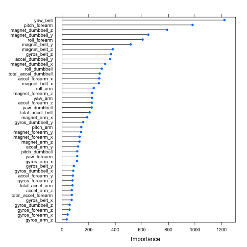

```r
plot(varImp(modelFit2,scale=FALSE))
```

This allows us to see perhaps for future analysis or manufacturing specification a few particular variables have an overriding amount of importance.

The testing set is loading, and modified as per the training set (for each model).

```r
temp2 <- tempfile()
download.file("https://d396qusza40orc.cloudfront.net/predmachlearn/pml-testing.csv", temp2,method="curl")
data2 <- read.csv(temp2)
data2[data2 == ""]<-NA
data2_mod<-data2[,which(as.numeric(colSums(is.na(data2)))==0)]
summary(data2_mod)
```

```
##        X            user_name raw_timestamp_part_1 raw_timestamp_part_2
##  Min.   : 1.00   adelmo  :1   Min.   :1.32e+09     Min.   : 36553
##  1st Qu.: 5.75   carlitos:3   1st Qu.:1.32e+09     1st Qu.:268655
##  Median :10.50   charles :1   Median :1.32e+09     Median :530706
##  Mean   :10.50   eurico  :4   Mean   :1.32e+09     Mean   :512167
##  3rd Qu.:15.25   jeremy  :8   3rd Qu.:1.32e+09     3rd Qu.:787738
##  Max.   :20.00   pedro   :3   Max.   :1.32e+09     Max.   :920315
##
##           cvtd_timestamp new_window   num_window    roll_belt
##  30/11/2011 17:11:4      no:20      Min.   : 48   Min.   : -5.92
##  05/12/2011 11:24:3                 1st Qu.:250   1st Qu.:  0.91
##  30/11/2011 17:12:3                 Median :384   Median :  1.11
##  05/12/2011 14:23:2                 Mean   :380   Mean   : 31.31
##  28/11/2011 14:14:2                 3rd Qu.:467   3rd Qu.: 32.51
##  02/12/2011 13:33:1                 Max.   :859   Max.   :129.00
##  (Other)         :5
##    pitch_belt        yaw_belt     total_accel_belt  gyros_belt_x
##  Min.   :-41.60   Min.   :-93.7   Min.   : 2.00    Min.   :-0.500
##  1st Qu.:  3.01   1st Qu.:-88.6   1st Qu.: 3.00    1st Qu.:-0.070
##  Median :  4.66   Median :-87.8   Median : 4.00    Median : 0.020
##  Mean   :  5.82   Mean   :-59.3   Mean   : 7.55    Mean   :-0.045
##  3rd Qu.:  6.13   3rd Qu.:-63.5   3rd Qu.: 8.00    3rd Qu.: 0.070
##  Max.   : 27.80   Max.   :162.0   Max.   :21.00    Max.   : 0.240
##
##   gyros_belt_y     gyros_belt_z     accel_belt_x     accel_belt_y
##  Min.   :-0.050   Min.   :-0.480   Min.   :-48.00   Min.   :-16.0
##  1st Qu.:-0.005   1st Qu.:-0.138   1st Qu.:-19.00   1st Qu.:  2.0
##  Median : 0.000   Median :-0.025   Median :-13.00   Median :  4.5
##  Mean   : 0.010   Mean   :-0.101   Mean   :-13.50   Mean   : 18.4
##  3rd Qu.: 0.020   3rd Qu.: 0.000   3rd Qu.: -8.75   3rd Qu.: 25.5
##  Max.   : 0.110   Max.   : 0.050   Max.   : 46.00   Max.   : 72.0
##
##   accel_belt_z    magnet_belt_x   magnet_belt_y magnet_belt_z
##  Min.   :-187.0   Min.   :-13.0   Min.   :566   Min.   :-426
##  1st Qu.: -24.0   1st Qu.:  5.5   1st Qu.:578   1st Qu.:-398
##  Median :  27.0   Median : 33.5   Median :600   Median :-314
##  Mean   : -17.6   Mean   : 35.1   Mean   :602   Mean   :-347
##  3rd Qu.:  38.2   3rd Qu.: 46.2   3rd Qu.:631   3rd Qu.:-305
##  Max.   :  49.0   Max.   :169.0   Max.   :638   Max.   :-291
##
```

[output cut: 65 more lines]

```
##  Min.   :-1.2600   Min.   :-212.0   Min.   :-331.0   Min.   :-282.0
##  1st Qu.:-0.0975   1st Qu.:-114.8   1st Qu.:   8.5   1st Qu.:-199.0
##  Median : 0.2300   Median :  86.0   Median : 138.0   Median :-148.5
##  Mean   : 0.2610   Mean   :  38.8   Mean   : 125.3   Mean   : -93.7
##  3rd Qu.: 0.7625   3rd Qu.: 166.2   3rd Qu.: 268.0   3rd Qu.: -31.0
##  Max.   : 1.8000   Max.   : 232.0   Max.   : 406.0   Max.   : 179.0
##
##  magnet_forearm_x magnet_forearm_y magnet_forearm_z   problem_id
##  Min.   :-714.0   Min.   :-787     Min.   :-32      Min.   : 1.00
##  1st Qu.:-427.2   1st Qu.:-329     1st Qu.:275      1st Qu.: 5.75
##  Median :-189.5   Median : 487     Median :492      Median :10.50
##  Mean   :-159.2   Mean   : 192     Mean   :460      Mean   :10.50
##  3rd Qu.:  41.5   3rd Qu.: 721     3rd Qu.:662      3rd Qu.:15.25
##  Max.   : 532.0   Max.   : 800     Max.   :884      Max.   :20.00
##
```

```r
data2_mod_clean<-data2_mod[,-c(1:7)]
```

The prediction is then performed.

```r
testingPC<-predict(preProc,data2_mod_clean[,-53])
pred_mod1<-predict(modelFit,testingPC)
```

```r
data2_mod_clean_hand<-data2_mod_clean[,-correlated]
pred_mod2<- predict(modelFit2,data2_mod_clean_hand[,-43])
```

```r
pred_mod1;pred_mod2
```

```
##  [1] B A A A A B D B A A B C B A E E A B B B
## Levels: A B C D E
```

```
##  [1] B A B A A E D B A A B C B A E E A B B B
## Levels: A B C D E
```

```r
pml_write_files = function(x){
  n = length(x)
  for(i in 1:n){
    filename = paste0("problem_id_",i,".txt")
    write.table(x[i],file=filename,quote=FALSE,row.names=FALSE,col.names=FALSE)
  }
}
pml_write_files(pred_mod2)
```